# AlphaSimR: Base population and traits

## Traits

With the founder genomes in perspective, we can proceed to add the characteristics of the target trait or traits to the simulation. AlphaSimR has a vignette that we recommend you take a look at. [link](https://cran.r-project.org/web/packages/AlphaSimR/vignettes/traits.pdf). It gives, thoroughly, an explanation on the traits of interest and how to interpret its effects.

### Single trait

#### **Additive trait**

We will start with a trait with only additive effects. For such, we have the following parameters:

```r
# Global simulation parameters from founder genomes.
SP = SimParam$new(founderGenomes)

# Additive trait
SP$addTraitA(nQtlPerChr = 15, # Number of QTL per trait
             mean = 10, # Trait mean
             var = 10) # Trait variance


# QTL effects (for the traits)
SP$traits[[1]]@addEff
```

```
##  [1] -0.546567125 -0.172941001  0.070973508  0.264658629  0.358995909
##  [6]  0.002254976  0.399134826  0.276348889 -0.271649273  0.781633031
## [11] -0.639272737  0.456972233 -0.320292116  0.432996337  0.855957665
## [16] -0.045579316  0.792610200 -0.050887586  0.411919567  0.818323904
## [21]  0.487439103 -0.579201260 -0.306537479 -0.317902699 -0.199013869
## [26]  0.552110206 -0.451372964 -0.140625427 -0.196572722 -0.165267591
## [31]  0.081825116 -0.101462798 -0.011991606  0.328152340 -0.216401711
## [36] -0.116284669  0.353892770 -0.525420295  0.134182702  0.042300529
## [41] -0.111455771 -0.508741678 -0.283784744  0.507688188 -0.333967744
```

After simulating the base genome and to set the trait characteristics, we can create individuals from that base genome for the trait of interest. We will use the function `newPop()`, as follows:

```r
# Creating individuals/population
basePop = newPop(founderGenomes)

# Looking at the population
# haplotypes
popHaplo = pullSegSiteHaplo(basePop)
popHaplo[, 1:10]
```

```
##     1_1 1_2 1_3 1_4 1_5 1_6 1_7 1_8 1_9 1_10
## 1_1   0   0   0   0   1   0   1   0   1    0
## 1_2   0   1   0   0   1   0   0   0   0    1
## 2_1   0   0   0   0   1   0   1   0   0    1
## 2_2   1   0   0   1   0   0   0   0   0    1
## 3_1   0   0   0   0   0   1   0   0   0    1
## 3_2   0   0   1   1   1   1   1   1   0    0
```

```r
# Check the genotypes
popGeno = pullSegSiteGeno(basePop)
popGeno[, 1:10]
```

```
##   1_1 1_2 1_3 1_4 1_5 1_6 1_7 1_8 1_9 1_10
## 1   0   1   0   0   2   0   1   0   1    1
## 2   1   0   0   1   1   0   1   0   0    2
## 3   0   0   1   1   1   2   1   1   0    1
```

#### Allele frequency

Allele frequency describes the proportion of mutations at a locus and can be estimated from the haplotypes (popHaplo object).

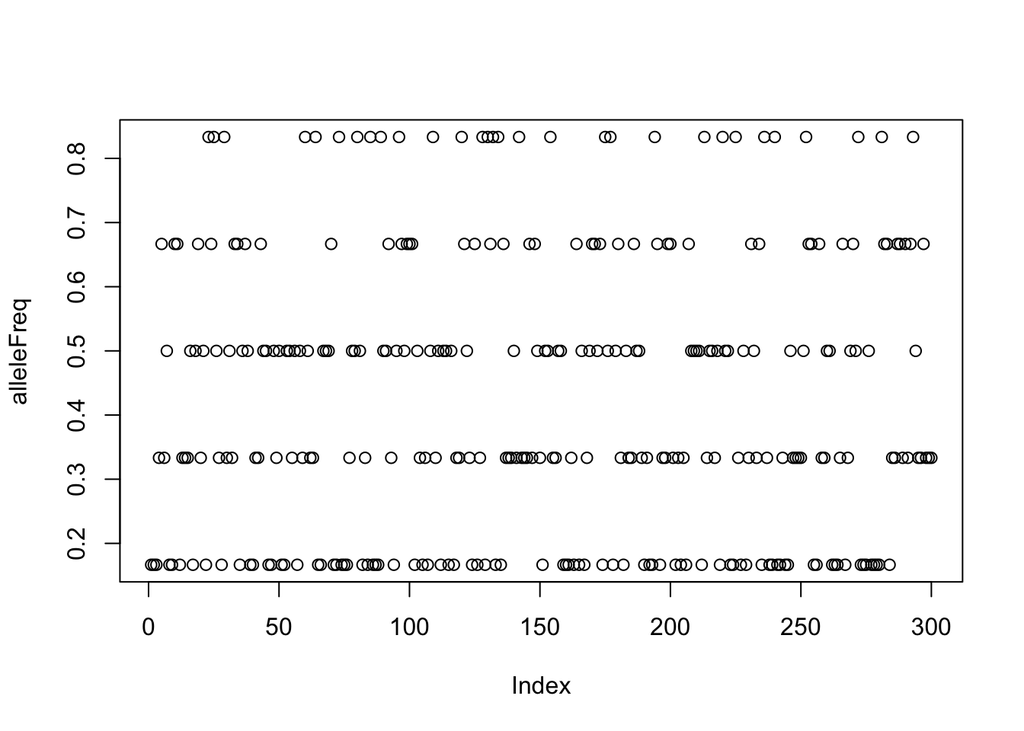

```r
# Allele frequency
alleleFreq = colMeans(popHaplo)

plot(alleleFreq)
```

#### **Trait with additive and dominance effects**

```r
# Global simulation parameters from founder genomes.
SP = SimParam$new(founderGenomes)

# Additive trait
SP$addTraitAD(nQtlPerChr = 15, # Number of QTLs controlling the trait per chromosome
              # nQtlPerChr = c(15, 5), # Alternative: QTL effect by chromosome
              mean = 10,
              var = 10,
              meanDD = 0.1, # dominance degree - it varies from 0-1 (meaning no-dominance and codominance)
              varDD = 0.2) # Variance for the degree of dominance

# QTL effects for additive effects
SP$traits[[1]]@addEff
```

```
##  [1] -3.3657435 -1.3320083 -1.5147922  0.1021749  2.3265190 -2.7704926
##  [7]  2.0163769  1.8741000  0.6206951  0.8713831  1.3624960  1.9962248
## [13]  0.9174940  1.8812546 -4.1344406  3.9762101 -0.4378657  0.2620290
## [19] -2.3698005  2.4323821  2.0516911  0.1060290  2.1220699  5.2698220
## [25] -1.1937975 -0.5387291  1.4626746  4.3278957 -2.0007115  1.2682065
## [31]  0.8762961  3.8196481  1.0837765  5.2030896 -4.1416200 -4.5523795
## [37]  1.4626581 -2.9242481  2.0259894  3.0859666 -1.9643857 -2.0638196
## [43] -0.2309161  0.3479297 -0.2343703
```

```r
# QTL effects for dominance effects
SP$traits[[1]]@domEff
```

```
##  [1]  1.3465517532  0.0454835863  1.1966961309 -0.0455383933  0.3179004172
##  [6]  0.4691929431  3.1845676401 -0.7873742585 -0.4285031860 -0.7531241743
## [11] -1.0912181837  0.0004296387 -0.0057244449  0.4397302838 -0.4058947901
## [16] -3.1171686145 -0.0030111637  0.1465321553  0.6374754311  1.1727062869
## [21]  0.1613364372  0.0876300864 -0.5154444511 -1.0201774022  0.2741164516
## [26]  0.0558109516 -0.4979928430  1.5217867218 -0.2637756579  0.8283008141
## [31]  0.1514059869  1.4306637950 -0.1533266145  2.4512339162 -0.8802727291
## [36] -2.4164087918  0.7875902594  1.2638231676  1.3311181259 -0.0127794162
## [41]  1.2518500348  1.0922202148 -0.0008851687  0.1418348809 -0.1056310878
```

The implementation of traits in `AlphaSimR` follows a biological model, which is responsible for converting into a genetic value each individual genotype before created. In a straightforward way, the genetic value is used to create the individuals’ phenotypes. The biological effects presented in `AlphaSimR` are:

**A**: additive effect  
**D**: dominance effect  
**G**: genotype by environment interaction effect  
**E**: environmental effect

So, we can create traits with the combinations of those effects (assuming that all of them as, at least, additive) using the **ADGE** framework, as it follows:

```r
# Traits that can be created in AlphaSimR:
SP$addTraitA()
SP$addTraitAD()
SP$addTraitADG()
SP$addTraitADEG()
SP$addTraitAG()
SP$addTraitAE()
SP$addTraitAEG()
```

It is important to have in mind that for dominance effects (**D**) we set the mean of the dominance degree (0-1) and variance, whereas for genotype by environment effect (**G**) and environmental effect (**E**) we have just to adjust the variance.

## Import External Data

The AlphaSimR package allows you to import genomic data and requires a genetic map and phased genotypes.

First, we load the genetic map in the format ‘Marker name, Chromosome, Position (in Morgans)’.

In the example below, we have a diploid species with 20 individuals, 10 chromosomes, each with 10 markers, and these markers are equally spaced along 1 Morgan chromosome.

```r
# Clean the directory
rm(list=ls())

# Load the External Data Set and Change the Directory
load("/Users/cazevedo/Downloads/BasePop_traits/External_Data.RDATA")

# Genetic map
head(genMap)
```

```
##   marker chromosome  position
## 1     M1          1 0.0000000
## 2     M2          1 0.1111111
## 3     M3          1 0.2222222
## 4     M4          1 0.3333333
## 5     M5          1 0.4444444
## 6     M6          1 0.5555556
```

```r
dim(genMap) # nrows: Number of markers
```

```
## [1] 100   3
```

If we have phased haplotypes, the file needs to be 40 rows (the number of individuals times the ploidy level), with each individual having 100 loci based on the map above.

```r
# Haplotype file
haplo[1:6,1:6]
```

```
##     M1 M2 M3 M4 M5 M6
## ID1  0  0  0  0  1  1
## ID1  1  0  0  0  1  0
## ID2  1  0  0  0  0  0
## ID2  0  0  1  0  1  0
## ID3  1  0  0  1  1  0
## ID3  0  0  0  1  0  1
```

```r
dim(haplo) # nrows: Number of individuals multiplied by ploidy level, and ncols: number of markers
```

```
## [1]  40 100
```

If we don’t have phased haplotypes, we can simulate the haplotype phases multiple times.

```r
# SNP matrix
snp[1:6,1:6]
```

```
##     M1 M2 M3 M4 M5 M6
## ID1  1  2  2  0  1  0
## ID2  0  0  2  1  2  1
## ID3  0  0  2  1  1  1
## ID4  0  2  0  2  2  1
## ID5  0  2  2  0  0  0
## ID6  1  1  2  2  2  2
```

```r
dim(snp) # nrows: Number of individuals and ncols: number of markers
```

```
## [1]  20 100
```

```r
# Load the function to simulate haplotype phase and Change the Directory
source("/Users/cazevedo/Downloads/BasePop_traits/Simulation_Haplotype_Phase.R")

# Haplotype file simulated
haplo=sim_haplo_phase(M=snp, ploidy=2)
haplo[1:6,1:6]
```

```
##      M1 M2 M3 M4 M5 M6
## [1,]  1  1  1  0  1  0
## [2,]  0  1  1  0  0  0
## [3,]  0  0  1  1  1  1
## [4,]  0  0  1  0  1  0
## [5,]  0  0  1  1  1  1
## [6,]  0  0  1  0  0  0
```

We can also import the pedigree file.

```r
# Pedigree file
head(ped)
```

```
##    id mother father
## 1 ID1      0      0
## 2 ID2      0      0
## 3 ID3      0      0
## 4 ID4      0      0
## 5 ID5      0      0
## 6 ID6      0      0
```

To create the founder genome using the imported data set, we can utilize the `importHaplo`function.

```r
# Create the founder population
founderPop = importHaplo(haplo = haplo,
                         genMap = genMap,
                         ploidy = 2,
                         ped = ped)
founderPop
```

```
## An object of class "NamedMapPop"
## Ploidy: 2
## Individuals: 20
## Chromosomes: 10
## Loci: 100
```

```r
# Set simulation parameters
# Initialize parameters with founder haplotypes
SP = SimParam$new(founderPop)
```

We can also load our own QTL effects or simulated traits using our imported genomic data set.

```r
# Load our own QTL effects
qtlEffects = data.frame(marker = c("M1", "M11","M80"),
                        aditiveEffect = c(1, -1, 1),
                        domEffect = c(0.3, 0, -0.3))

# Import in SimParam
SP$importTrait(markerNames = qtlEffects$marker,
               addEff = qtlEffects$aditiveEffect,
               intercept = 10,
               domEff = qtlEffects$domEffect,
               name = "Trait1")

# Create a population from the founder haplotypes
pop = newPop(founderPop)

# The population now works like any other AlphaSimR population
gv(pop)[1:6]
```

```
## [1] 11.3  7.7  9.0  8.0  9.7 10.0
```

### Multi-trait framework

The `AlphaSimR` package allows to simulate a set of traits for the individuals. For such, two strategies may be used.

The first strategy is to set all traits at once (using `$addTrait`). In this option, a correlation matrix between each pair of traits, for each effect, should be added, as follows:

```r
rm(list=ls())
# Founder genome
founderGenomes = runMacs(nInd = 3,
                         nChr = 3,
                         segSites = 100,
                         species = "MAIZE",
                         ploidy = 2)

# From the base population
SP = SimParam$new(founderGenomes)

# Alternative one - Setting the correlation between traits (Additive trait)
SP$addTraitA(nQtlPerChr = 20,
             mean = c(0, 10),
             var = c(0.5, 2),
             corA = matrix(c(1.0, 0.5,
                             0.5, 1.0), nrow = 2))


# QTL effects for trait one
SP$traits[[1]]@addEff
```

```
##  [1] -0.053878369  0.017295128  0.599970412 -0.149829906 -0.200954679
##  [6] -0.599911092 -0.597920803  0.212638442  0.406009860 -0.028062429
## [11]  0.625883234  0.367760726 -0.275222083  0.206115574 -0.092647632
## [16] -0.375329693 -0.182052422 -0.714819699  0.602638008 -0.036024517
## [21]  0.734180927 -0.051898660  0.099536355 -0.412049068  1.195895638
## [26]  0.023019811 -0.079530578  0.578082574  0.056038281  0.390553850
## [31] -0.053904427 -0.167902345 -0.229479603  0.014772642  0.409027867
## [36] -0.304388516 -0.064361877  0.097683135 -0.076246771 -0.054368272
## [41]  0.381824527  0.140407849 -0.263696420 -0.775503016 -0.229630492
## [46]  0.184307296  0.435474335 -0.596917509  0.171354468  0.044267210
## [51]  0.158205277  0.163088999  0.084413723  0.365323963 -0.095801382
## [56]  0.005041075  0.119698634 -0.371616828  0.996930420 -0.140294596
```

```r
# QTL effects for trait two
SP$traits[[2]]@addEff
```

```
##  [1] -0.33394548  2.56308968  3.22038677 -0.62398552 -2.53609789 -1.20597634
##  [7] -2.89695868  2.39721088 -2.03818645 -0.68367601  1.04187056  1.24665129
## [13] -1.56543317  0.67350633 -0.16811149 -1.20902181 -2.31965477 -1.30415477
## [19]  1.86808667 -1.19303642  0.28293046  2.93277208  3.63091310 -0.61298299
## [25]  0.50425866  0.45203096 -0.03911913 -0.66251002 -1.95776727  3.35239614
## [31] -0.65509862 -0.29477579 -0.05338840 -0.37593689  0.01650537  2.20118959
## [37]  1.17322708 -0.74151366 -0.66155863  2.74916209  0.90220482 -0.41908437
## [43] -1.91810855  0.38670036 -0.55297000 -1.51424271 -1.36117837  0.30970498
## [49] -1.08598047 -0.69554223 -0.15770541  0.22977410 -2.10922529  0.56036426
## [55]  1.73481511 -3.44123928 -2.22407305 -1.51161248  1.77966399 -0.19730920
```

A second strategy in a multi-trait framework is to add each trait individually. In this case, we do not need to add the information of correlation between them. Another positive aspect of this second strategy is the possibility of setting a different number of QTLs controlling each trait simulated.

```r
# From the base population
SP = SimParam$new(founderGenomes)

# Alternative two - One trait at a time

# Trait one
SP$addTraitA(nQtlPerChr = 20,
             mean = 0,
             var = 0.5)

# Trait two
SP$addTraitA(nQtlPerChr = 5,
             mean = 100,
             var = 20)

# QTL effects for trait one
SP$traits[[1]]@addEff
```

```
##  [1] -0.207535424  0.325608679 -0.209188175 -0.086479920  0.422712517
##  [6] -0.151190977 -0.058617857  0.238941353  0.196543086 -0.140279074
## [11] -0.086233932  0.103329255 -0.057635574 -0.083120442  0.676204339
## [16] -0.353758446 -0.416210847  0.149198188 -0.368817605 -0.528009913
## [21] -0.177124252 -0.230905226  0.295215027  0.101304070 -0.256778798
## [26]  0.289528568  0.101525525  0.093818772  0.224463663 -0.094849899
## [31]  0.092774327 -0.055699585 -0.104897064 -0.043986425  0.514894911
## [36]  0.009033850  0.209830833 -0.277500573  0.093201724  0.330742850
## [41]  0.117228969 -0.440029387 -0.201512906  0.120133784 -0.093472930
## [46] -0.173883246  0.112192125 -0.202789478 -0.154477666 -0.060387565
## [51]  0.006451664 -0.101150886 -0.039000849  0.163876411 -0.027351494
## [56] -0.028407757  0.036649492  0.077952337 -0.311686297  0.312827171
```

```r
# QTL effects for trait two
SP$traits[[2]]@addEff
```

```
##  [1]  4.00757809  1.49617338 -0.63801772 -1.68862988  1.74178898 -0.53231194
##  [7]  0.22858744  1.69581783  0.41580658 -1.70133066 -1.50619810  0.04057156
## [13]  3.88086777 -0.33338998 -0.40158544
```

### Split argument

In breeding programs, such as maize, heterosis is harnessed by exploiting the crosses between heterotic groups. Usually, two distinct groups are used (*i*.*e*., maize dent and flint germplasm pools). The genetic divergence of these two pools is explained by their historic geographical separation and adaptation to different environments. It has undergone changes in the population structure and history of the base population.

For simulations that involve population separation in terms of generations, the **AlphaSimR** package offers the split argument in the `runMacs()` function. It represents an optional historic population split in terms of generations ago.

Below, we will simulate three different base genomes. The first one will use the default value (NULL) for the split argument. The second and third genomes will be split 10 and 50 generations ago, respectively. We will examine the base genome genotypes and explore them through a principal component analysis (PCA).

```r
rm(list=ls())
#------------------- Founder genome with no split
founderGenomes = runMacs(nInd = 200,
                         nChr = 5,
                         segSites = 100,
                         species = "MAIZE",
                         ploidy = 2,
                         split = NULL)

# From the base population
SP = SimParam$new(founderGenomes)

# Creating individuals/population
basePop = newPop(founderGenomes)

# Check the genotypes
popGeno = pullSegSiteGeno(basePop)

# PCA
pca_noSplit = prcomp(popGeno)

#------------------- Founder genome with no split
founderGenomes = runMacs(nInd = 200,
                         nChr = 5,
                         segSites = 100,
                         species = "MAIZE",
                         ploidy = 2,
                         split = 10)

# From the base population
SP = SimParam$new(founderGenomes)

# Creating individuals/population
basePop = newPop(founderGenomes)

# Check the genotypes
popGeno_10 = pullSegSiteGeno(basePop)

# PCA
pca_Split10 = prcomp(popGeno_10)


#------------------- Founder genome with no split
founderGenomes = runMacs(nInd = 200,
                         nChr = 5,
                         segSites = 100,
                         species = "MAIZE",
                         ploidy = 2,
                         split = 50)

# From the base population
SP = SimParam$new(founderGenomes)

# Creating individuals/population
basePop = newPop(founderGenomes)

# Check the genotypes
popGeno_50 = pullSegSiteGeno(basePop)

# PCA
pca_Split50 = prcomp(popGeno_50)
```

Plotting the PCA from each base population created.

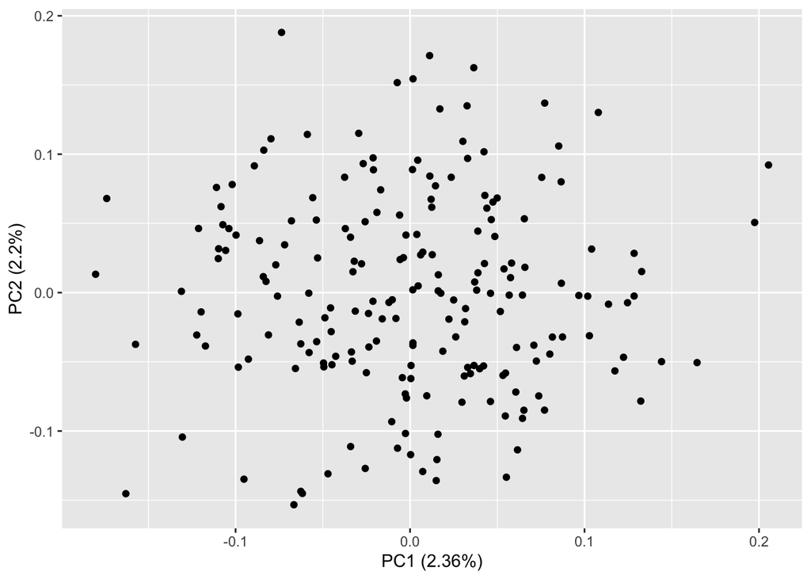

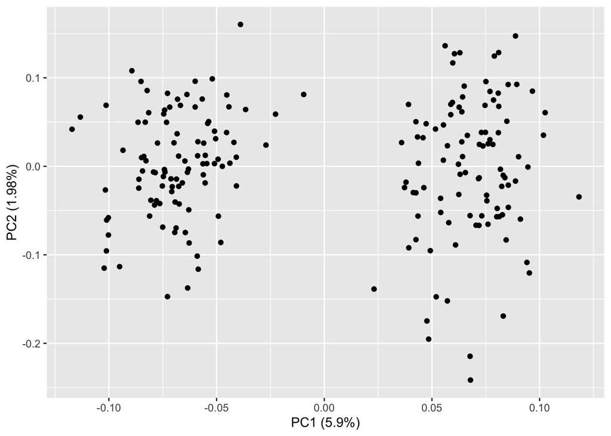

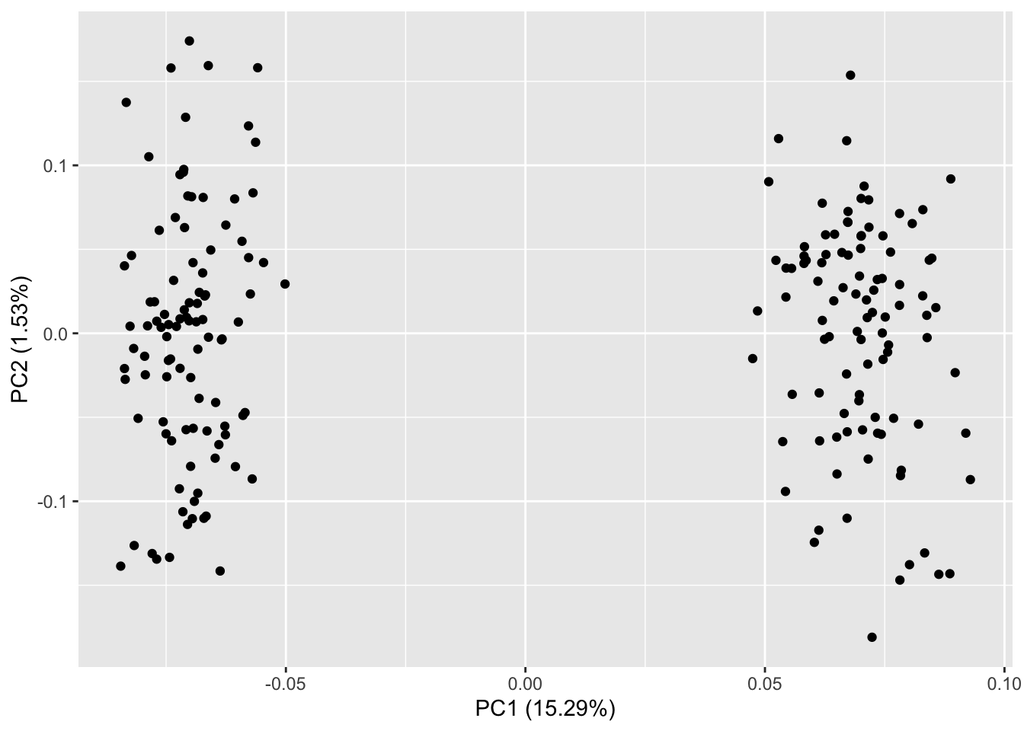

```r
# Plotting the PCA
library(ggfortify)
# Plot
par(mar = c(1, 3, .1, .1))
autoplot(pca_noSplit, data = popGeno)
autoplot(pca_Split10, data = popGeno_10)
autoplot(pca_Split50, data = popGeno_50)
```

## References

Chen, Gary K, Paul Marjoram, and Jeffrey D Wall. 2009. “Fast and Flexible Simulation of DNA Sequence Data.” *Genome Research* 19 (1): 136–42.

Gaynor, R Chris, Gregor Gorjanc, and John M Hickey. 2021. “AlphaSimR: An r Package for Breeding Program Simulations.” *G3* 11 (2): jkaa017.

[^1]: Professor - University of Florida, mresende@ufl.edu
[^2]: Post doc - University of Florida, deamorimpeixotom@ufl.edu
[^3]: Professor - University of Florida, lferrao@ufl.edu
[^4]: Professor - Federal University of Viçosa, camila.azevedo@ufv.br